# Salmon spatiotemporal fecundity estimates

DIASPARA WP 2.2

Author

Viktor Thunell

Published

February 24, 2026

## Introduction

Fish fecundity (the number of eggs per spawning female) is a key life history trait reflecting fitness resulting from evolutionary trade-offs and environmental conditions (Lambert 2008). In Atlantic salmon, *Salmo salar*, where semelparity is common (and generally the case in the North Atlantic while iteroparity is dominating in Baltic sea populations), fecundity becomes pivotal for individual reproductive potential and important for population dynamics (Crespi and Teo 2002; Jonsson and Jonsson 2017). Fecundity is body size dependent with individual length being a suitable quantitative predictor (Lambert 2008). Changes in the size of salmon returning to spawn can therefore be used to calculate a proxy for changes in their reproductive potential over time when temporally resolved fecundity data is missing (Nevoux et al. 2020), as in the case for the analysis of salmon fecundity in DIASPARA.

The working group on North Atlantic salmon (WGNAS) uses information on fecundity to estimate egg deposition for spawners that spent one or multiple winters in their marine phase (sea winters, SW). These estimate are stock unit specific and can vary over time. Here, knowledge of spatiotemporal changes in fecundity is key as the reproductive potential of many stock units assessed by WGNAS is at historically low levels (ICES 2025b).

The Assessment Working Group on Baltic Salmon and Trout (WGBAST) uses fecundity by sea winter age but this is currently not stock specific and is time invariant. Consequently, knowledge on changes in fecundity over time can help prioritize needs in future improvements of the stock assessment model (ICES 2025a).

To address these issues, we combine the spatial model for fecundity at length with the spatiotemporal model for length at age to produce spatiotemporal estimates of fecundity of salmon with varying number of winters spent at sea. A key assumption for this analyses is that individual fecundity is not subject to environmental variation nor evolutionary processes.

In detail, we propagate the uncertainty in spatial fecundity parameters $a_j$ and $b_j$ (for spatial unit $j$, see main text, section *Spatial variation in salmon fecundity - Model description*) to estimates of fecundity over time ($F_{y,j}$ in year $y$) by combining posterior draws of fecundity parameters $a$ and $b$ from the fecundity at length model with posterior draws of $l_{\mu}$ (predicted length at age) by spatial unit, cohort, age (growth year), and smolt age. Following the model formulation (main text), we calculate fecundity on the $log$ scale based on mean centered $log$ length:

$$log(F_{y,j}) = a_j + b_j \times \log\left(\frac{l_{\mu}}{\bar{l_{\mu}}}\right)$$

As the model for length at age is smolt age specific, we predict spatiotemporal fecundity for smolt ages used in the assessment models. In the Baltic (for WGBAST) this is two year old smolts for Assessment Unit AU3 and three year old smolts in AU1 and AU2 (and we lack fecundity estimates for AU4-6). For the North Atlantic salmon and the WGNAS LCM model this is smolt ages 1-6, however fecundity is only predicted for existing smolt ages for a spatial unit.

## Combine length and fecundity MCMC samples

```r
# read fecundity at length samples
fec.samples <- readRDS(paste0(home,"/models_salmon/samples/fec_samples_2026-01-15.RData"))$samples %>%
  spread_draws(a[su],b[su]) %>%
  # remove draws aove 1500 to match number with laa samples
  filter(.draw <= 1500) %>%
  left_join(data.fec %>% distinct(su, spat.unit)) %>%
  ungroup() %>%
  select(-su,-.iteration,-.chain )

# read length at age mcmc samples
laa.samples <- readRDS(paste0(home,"/models_salmon/samples/salaa_samples_2025-12-22.RData"))$samples

masu <- data.biph %>%
  filter(!is.na(smo.age)) %>%
  summarise(ma = max(g.year), .by = su) %>%
  arrange(su)

# select the expected value parameter l.mu
node.sub <- grep("l.mu", colnames(laa.samples[[1]]), value = TRUE)
laa.samples_2 <- laa.samples[, node.sub[], drop = FALSE] %>%
  spread_draws(l.mu[su,smo.age,coh,sex,gy], sep = ",") %>%
  # remove males and draw 1501 and 1 (a few NA l.mu:s there)
  filter(sex == 1,
         gy %in% c(smo.age+2, smo.age+3, smo.age+4, smo.age+5, smo.age+6, smo.age+7),
         .draw <= 1500 & .draw > 1
         ) %>%
  left_join(data.biph %>% distinct(su, spat.unit)) %>%
  # filter out the spatial units for which we have fecundity estimates
  filter(spat.unit %in% unique(fec.samples$spat.unit)) %>%
  # filter out the most common smolt age per spatial unit and maximum ages
  filter(#smo.age == mosa[su,2],
         gy <= masu[su,2]) %>%
  ungroup() %>%
  select(-sex,-su,-.iteration,-.chain )
```

## Calculate fecundity per MCMC draw

```r
lf.samples <- laa.samples_2 %>%
  # join in mcmc draws of a and b from fecundity model
  left_join(fec.samples,  by = c("spat.unit",".draw")) %>%
  mutate(length.lc = log(l.mu) - log(mean(l.mu)),
         fecundity = exp(a + b * length.lc),
         year = coh + gy + 1998) %>%
  rename(length = l.mu)
```

## Results

Changes in fecundity over time is presented for 1 and 2 SW spawners with posterior uncertainty in Figure 1 and Figure 2, for 3-5SW Baltic spawners in Figure 3, and for all ages spawners that has occurred within the spatial units in the analysed time frame (Figure 5,without posterior uncertainty). The dependence on smolt age in our biphasic growth model for North Atlantic salmon, resulting in variation in fecundity is shown in Figure 4.

Note that the temporal pattern in this analysis reflect changes in length for fish returning to spawn and spatial-unit-specific length-fecundity relationships (see main text). The length at age of salmon here follows a von Bertalanffy type growth trajectory and differences between the ages of salmon within a spatial unit and year will differ with an offset given by their growth trajectory. This effect is dependent on the temporal trend in the von Bertalanffy growth coefficient $k$ and as growth levels off with age, changes in $k$ with time has stronger effects on yong spawners compared to older spawners (compare e.g. 1 and 3 SW fecundity in Ireland_west, Figure 5).

Given the considerable change in fecundity resulting from changes in length in the North Atlantic spatial units, it should have large consequences for the reproductive capacity of the stocks given that common age at spawning remains constant.

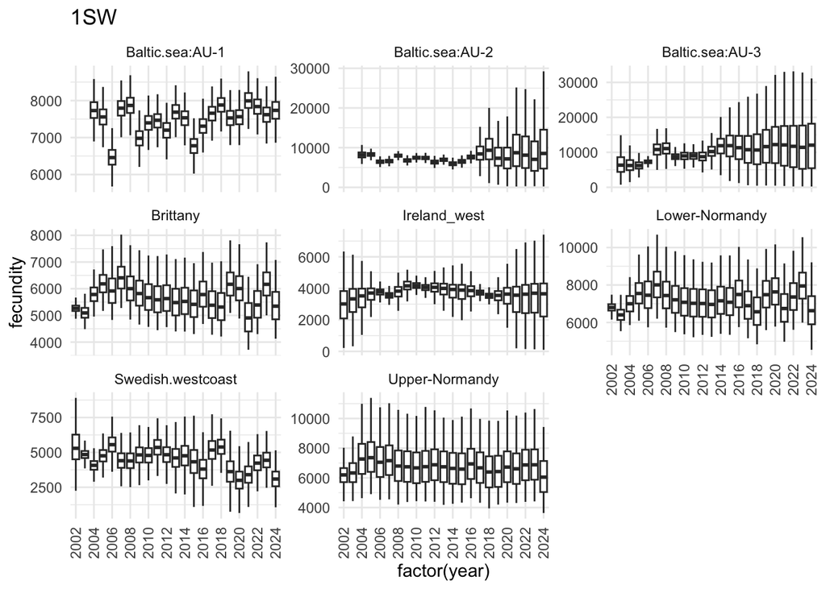

Figure 1: Fecundity (number of eggs) of 1SW salmon over time by spatial unit (both North Atlantic and Baltic). In the Baltic sea, smolt age 2 in shown for Assessment Unit AU3 and smolt age 3 in AU1 and AU2, for the North Atlantic salmon, fecundity is marginalised over smolt ages. Boxplots summarise the posterior draws for each year and spatial unit where the center line is the median, boxes and whiskers show the IQR and 1.5 times IQR and outliers are excluded.

```r
lf.samples %>%
  filter(
    # WGBAST assume 3 year old smolt in AU1 or 2, and 2 year old smolts in AU 3 and 4.
    !(spat.unit %in% c("Baltic.sea:AU-1","Baltic.sea:AU-2") & !smo.age == 3),
    !(spat.unit %in% c("Baltic.sea:AU-3","Baltic.sea:AU-4") & !smo.age == 2),
    gy == smo.age+2, # 1SW
         year < 2025,
         #!spat.unit %in% c("Baltic.sea:AU-2","Baltic.sea:AU-3")
         ) %>%
  ggplot() +
  geom_boxplot(aes(y = fecundity, x = factor(year)),
               outliers = FALSE, show.legend = FALSE) +
  facet_wrap(~spat.unit, scales = "free_y") +
  scale_x_discrete(breaks = seq(min(lf.samples$year), max(lf.samples$year), by = 2)) +
  theme_minimal() +
  theme(axis.text.x = element_text(angle = 90, vjust = 0.5)) +
  labs(title = "1SW")
```

```
filter: removed 4,715,854 rows (88%), 643,071 rows remaining
```

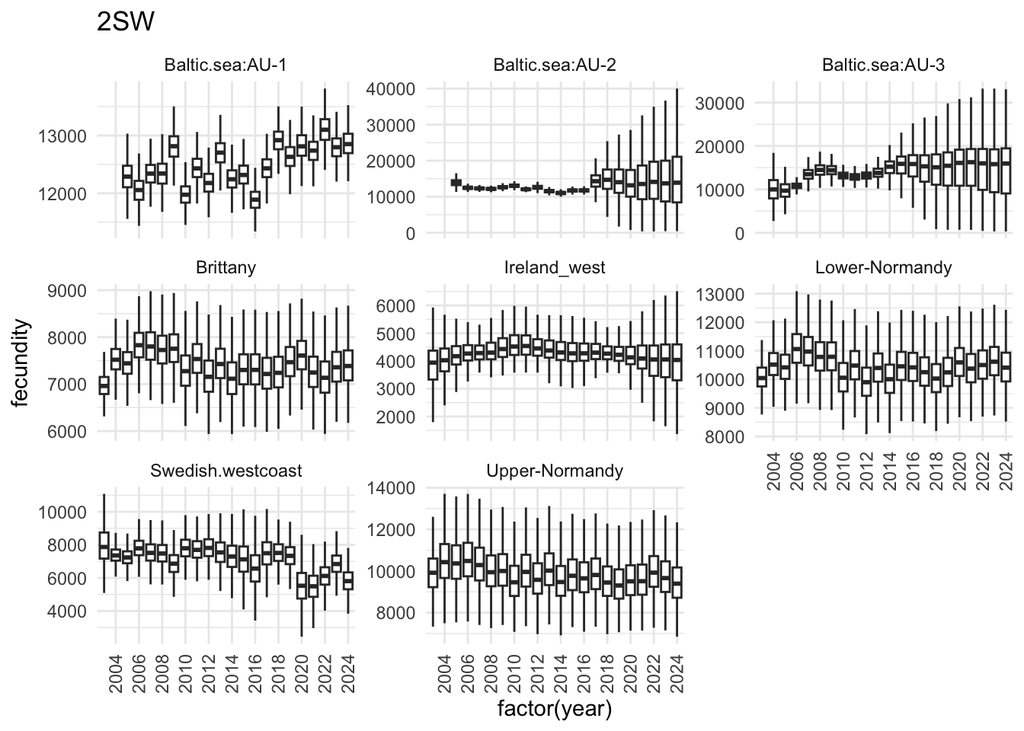

Figure 2: Fecundity (number of eggs) of 2SW salmon over time by spatial unit (both North Atlantic and Baltic). In the Baltic sea, smolt age 2 in shown for Assessment Unit AU3 and smolt age 3 in AU1 and AU2, for the North Atlantic salmon, fecundity is marginalised over smolt ages. Boxplots summarise the posterior draws for each year and spatial unit where the center line is the median, boxes and whiskers show the IQR and 1.5 times IQR and outliers are excluded.

```r
lf.samples %>%
  filter(# WGBAST assume 3 year old smolts in AU1 or 2, and then 2 year old smolts in AU 3 and 4.
    !(spat.unit %in% c("Baltic.sea:AU-1","Baltic.sea:AU-2") & !smo.age == 3),
    !(spat.unit %in% c("Baltic.sea:AU-3","Baltic.sea:AU-4") & !smo.age == 2),
    gy == smo.age+3,
    # remove years (2025) without data
    year < 2025) %>%
  ggplot() +
  geom_boxplot(aes(y = fecundity, x = factor(year)),
               outliers = FALSE, show.legend = FALSE) +
  facet_wrap(~spat.unit, scales = "free_y") +
  theme_minimal() +
  scale_x_discrete(breaks = seq(min(lf.samples$year), max(lf.samples$year), by = 2)) +
  theme(axis.text.x = element_text(angle = 90, vjust = 0.5)) +
  labs(title = "2SW")
```

```
filter: removed 5,138,572 rows (96%), 220,353 rows remaining
mutate: new variable 'SW' (character) with 3 unique values and 0% NA
```

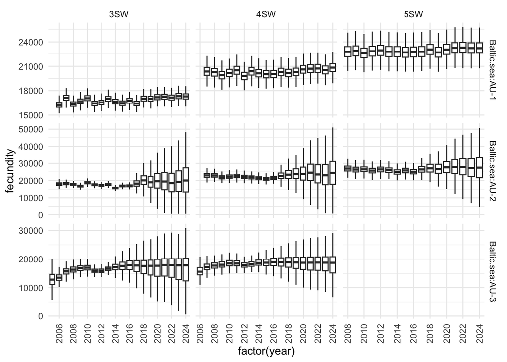

Figure 3: Fecundity (number of eggs) of 3-5SW salmon over time by spatial unit in the Baltic sea for smolt age 2 in Assessment Unit AU3 and smolt age 3 in AU1 and AU2. Boxplots summarise the posterior draws for each year and spatial unit where the center line is the median, boxes and whiskers show the IQR and 1.5 times IQR and outliers are excluded.

```r
lf.samples %>%
  filter(case_when(
    # WGBAST assume 3 year old smolts in AU1 or 2, and then 2 year old smolts in AU 3 and 4.
    spat.unit %in% c("Baltic.sea:AU-1","Baltic.sea:AU-2") ~ smo.age == 3,
    spat.unit %in% c("Baltic.sea:AU-3","Baltic.sea:AU-4") ~ smo.age == 2),
    # filter out 3, 4 and 5 SW
    gy == (smo.age + 4) | gy == (smo.age + 5) | gy == (smo.age + 6),
    #gy %in% c(smo.age+4,smo.age+5,smo.age+6)) %>%
   year < 2025) %>%
  mutate(SW = paste0(gy-smo.age-1,"SW")) %>%
  ggplot() +
  geom_boxplot(aes(y = fecundity, x = factor(year)),
               outliers = FALSE, show.legend = FALSE) +
  facet_grid(spat.unit~SW, scales = "free") +
  scale_x_discrete(breaks = seq(min(lf.samples$year), max(lf.samples$year), by = 2)) +
  theme_minimal() +
  theme(axis.text.x = element_text(angle = 90, vjust = 0.5))
```

```
filter: removed 4,137,240 rows (77%), 1,221,685 rows remaining
mutate: new variable 'SW' (character) with 2 unique values and 0% NA
```

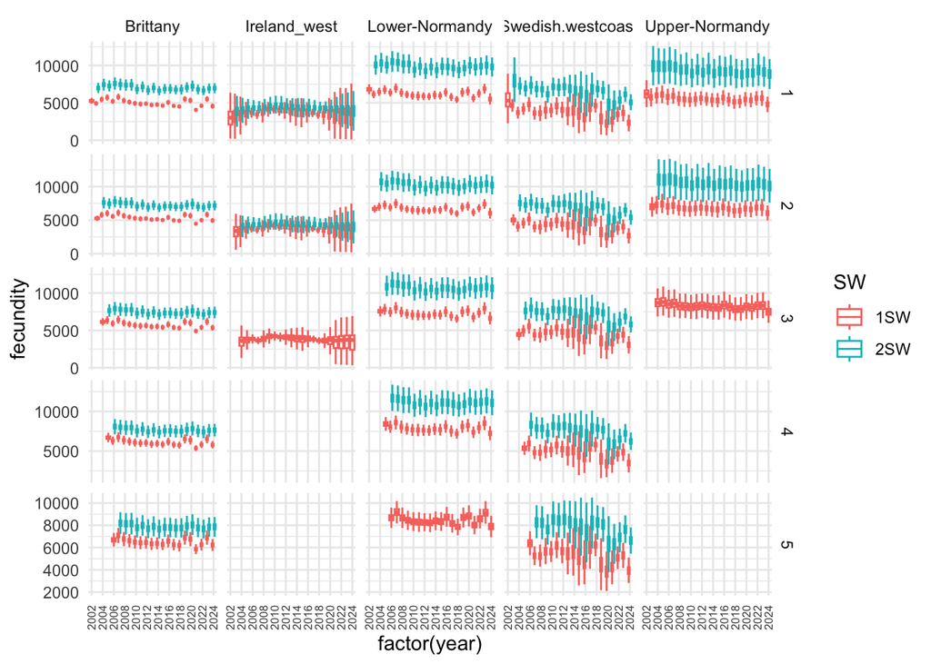

Figure 4: Fecundity (number of eggs) of 1 and 2SW salmon over time by North Atlantic spatial units (columns) and smolt age 1-5 (rows). Boxplots summarise the posterior draws for each year and spatial unit where the center line is the median, boxes and whiskers show the IQR and 1.5 times IQR and outliers are excluded.

```r
lf.samples %>%
  filter(# WGBAST assume 3 year old smolts in AU1 or 2, and then 2 year old smolts in AU 3 and 4.
    !str_detect(spat.unit,"AU"),
    gy == (smo.age + 2) | gy == (smo.age + 3),
    # remove years (2025) without data
    year < 2025) %>%
  mutate(SW = paste0(gy-smo.age-1,"SW")) %>%
  ggplot() +
  geom_boxplot(aes(y = fecundity, x = factor(year), color = SW),
               outliers = FALSE) +
  facet_grid(smo.age~spat.unit, scales = "free_y") +
  scale_x_discrete(breaks = seq(2002, 2024, by = 2)) +
  theme_minimal() +
  theme(axis.text.x = element_text(angle = 90, vjust = 0.5, size = rel(.7)))
```

```
group_by: 3 grouping variables (year, gy, spat.unit)
filter: removed 253 rows (22%), 922 rows remaining
```

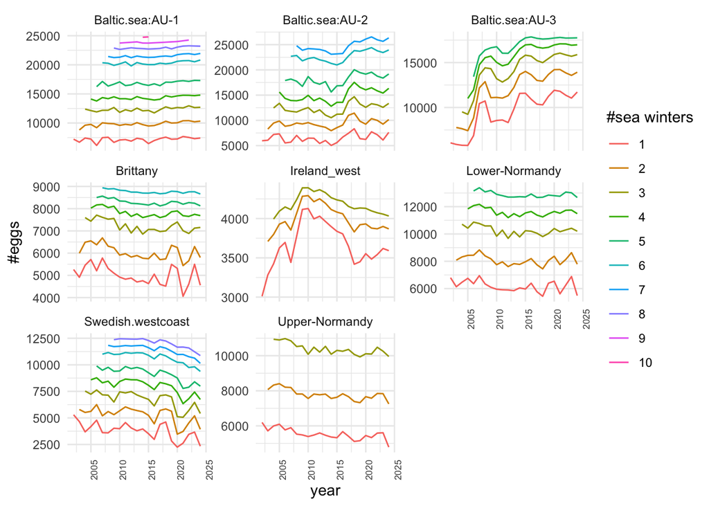

```r
lf.samples %>%
  group_by(year,gy,spat.unit) %>%
  median_qi(fecundity) %>%
  # remove years (2025) without data
  filter(year < 2025,
         !fecundity == 0) %>%
  ggplot() +
  # minus 2 because gy = 2 is 1SW (smo.age is age = 0 and gy is age+1)
  geom_line(aes(y = fecundity, x = year, color = factor(gy-2))) +
  facet_wrap(~spat.unit, scales = "free_y") +
  theme_minimal() +
  theme(axis.text.x = element_text(angle = 90, hjust = 1, size = rel(.75))) +
  labs(color = "#sea winters", y = "#eggs")
```

## References

Crespi, Bernard J., and Roy Teo. 2002. “COMPARATIVE PHYLOGENETIC ANALYSIS OF THE EVOLUTION OF SEMELPARITY AND LIFE HISTORY IN SALMONID FISHES.” *Evolution* 56 (5): 1008–20. https://doi.org/https://doi.org/10.1111/j.0014-3820.2002.tb01412.x.

ICES. 2025a. “Baltic Salmon and Trout Assessment Working Group (WGBAST),” May. https://doi.org/10.17895/ices.pub.29118545.v2.

———. 2025b. “Working Group on North Atlantic Salmon (WGNAS),” May. https://doi.org/10.17895/ices.pub.28777226.v1.

Jonsson, Bror, and Nina Jonsson. 2017. “Fecundity and Water Flow Influence the Dynamics of Atlantic Salmon.” *Ecology of Freshwater Fish* 26 (3): 497–502. https://doi.org/https://doi.org/10.1111/eff.12294.

Lambert, Yvan. 2008. “Why Should We Closely Monitor Fecundity in Marine Fish Populations?” *Journal of Northwest Atlantic Fishery Science* 41: 93–106. https://doi.org/10.2960/J.v41.m637.

Nevoux, M., E. Rivot, S. Gregory, F. Marchand, A-L. Besnard, L. Meslier, T. Jousseaume, S. Launey, A. King, and J. Stevens. 2020. “Changes in Sex Ratio and Fecundity of Salmonids.” Deliverable D3.3.1. SAMARCH project.